# Median transform

We present the median transform as a pre-processing step for unsupervised one-class classification and anomaly detection. The median transform is applied as a pre-processing step to generate a new dataset assumed to consist only of target (inlier) objects. Any one-class classifier can then be trained on the median-transformed data to classify new objects as inliers or outliers.

# Median transform

The median transform can transform an unlabeled data matrix into another of same size such that each object of the original dataset is replaced by a hypothetical “median” object of its $k$ nearest neighbors. The median object is computed by considering the median value of each feature from among the $k$ nearest neighbors.

The transform requires setting the parameter $k$ representing the number of neighbors to consider. The larger $k$ is, the greater is the effect of the median transform in eliminating outlier objects by replacing these with more in-bound objects.

The median transform can address the case of *unsupervised* anomaly detection, that is, when there is complete absence of target/outlier labels to train on. The transform is applied as a pre-processing step to ensure that the new (transformed) dataset is outlier-free, consisting only of target objects. Any one-class classifier can then be applied on the transformed dataset.

The median transform is implemented below as the function `mediantx()`. It accepts an unlabeled data matrix $\textbf{X}$ and a single parameter $k$, the number of neighbors.

```r
mediantx <- function(X, k = 10, verbose =  TRUE){
  #Median transform
  #X: unlabeled data in standard format (matrix type)
  #k: the number of neighbors
  #Description: generates a new dataset of same size as X by replacing each object in X...
  #...with the 'median' object from within its k-nearest neighbors. The median object is...
  #...computed from the k-nearest neighbors by considering the median value for each feature.

  if (!require("rdist")) install.packages("rdist")
  library("rdist")

  X <- as.matrix(X)
  n <- dim(X)[1] #number of objects
  p <- dim(X)[2] #number of features
  k <- k + 1 #increment k to account for object itself in distance matrix

  #scalable version to avoid memory overload.
  if (n > 1000){
    #use blocks of at most 1000 objects at a time
    Q <- array(0,dim=c(1000,p,ceiling(n/1000)))
    flag <- 0 #block contains 1000 objects
    for (i in 1:ceiling(n/1000)){
      tmp <- X[(1000*(i-1)+1):min(1000*i,n),,drop=FALSE]
      if(dim(tmp)[1] < 1000) {
        #pad the block with 0s to size 1000
        pad <- rbind(tmp,matrix(0,nrow=1000-dim(tmp)[1],ncol=p))
        Q[,,i] <- pad
        flag <- 1 #(final) block contains less than 1000 objects
        realsize <- dim(tmp)[1]
      }
      else Q[,,i] <- tmp
    }

    #each block within matrices 'corrected_order' and 'dist' is reduced to k columns.
    corrected_order <- matrix(NA,nrow=1000*ceiling(n/1000),ncol=k*ceiling(n/1000))
    dist <- matrix(NA,nrow=1000*ceiling(n/1000),ncol=k*ceiling(n/1000))
    for (i in 1:(ceiling(n/1000))){
      if(verbose) print(paste("training: batch...",ceiling(n/1000)-i))
      for (j in 1:(ceiling(n/1000))){
        block <- cdist(Q[,,i],Q[,,j],metric="euclidean")
        if (j == ceiling(n/1000) & flag == 1) {
          #block has less than 1000 objects
          o <- t(apply(block[,1:realsize],1,order,decreasing=FALSE))
          sorted <- t(apply(block[,1:realsize],1,sort,decreasing=FALSE))
          mn <- min(k,realsize) #in case last block contains less than k (non-padded) objects
          corrected_order[(1000*(i-1)+1):(1000*i),(1+((j-1)*k)):(mn+((j-1)*k))] <- o[,1:mn,drop=FALSE] + (1000*(j-1))
          dist[(1000*(i-1)+1):(1000*i),(1+((j-1)*k)):(mn+((j-1)*k))] <- sorted[,1:mn,drop=FALSE]
        }
        else {
          #block is 1000 x 1000
          o <- t(apply(block,1,order,decreasing=FALSE))
          sorted <- t(apply(block,1,sort,decreasing=FALSE))
          corrected_order[(1000*(i-1)+1):(1000*i),(1+((j-1)*k)):(k+((j-1)*k))] <- o[,1:k,drop=FALSE] + (1000*(j-1))
          dist[(1000*(i-1)+1):(1000*i),(1+((j-1)*k)):(k+((j-1)*k))] <- sorted[,1:k,drop=FALSE]
        }
      }
    }
    #smallest k distances overall, out of finalist groups containing k candidates each
    if (dim(dist)[2]==1) {
      O <- matrix(1,nrow=nrow(dist),ncol=1)
    }
    else {
      O <- t(apply(dist,1,order,decreasing=FALSE))[,2:k,drop=FALSE]
    }
    nn <- matrix(NA,nrow=dim(O)[1],ncol=k-1)
    for (i in 1:dim(O)[1]){
      nn[i,] <- corrected_order[i,O[i,],drop=FALSE] #order of nearest k neighbors in full distance matrix
    }
    nn <- nn[1:n,,drop=FALSE] #remove part corresponding to artificially padded section
    Y <- matrix(NA,n,p)
    for (i in 1:n){
      Y[i,] <- apply(X[nn[i,], ,drop=FALSE],2,median) #compute median feature values
    }
  }
  #otherwise if n<=1000 objects, compute full distance matrix in one shot.
  else {
    DistMat <- pdist(X,metric="euclidean") #distance matrix
    Y <- matrix(NA,n,p)
    for (i in 1:n){
      ordered_neighbors <- order(DistMat[i, ])
      nn <- ordered_neighbors[2:k] #include object itself as 1st nearest neighbor
      Y[i,] <- apply(X[nn,,drop=FALSE],2,median)
    }
  }
  return(Y)
}
```

# Demo

We try out the median transform on two datasets: one consisting of two boomerang-shaped branches each with 2000 objects and another consisting of a main Gaussian blob of 500 objects with a distant ‘island’ of (five) outliers. For each dataset, different values of $k$ are tested out. The transformed data should consist solely of what is expected to be target (inlier) objects.

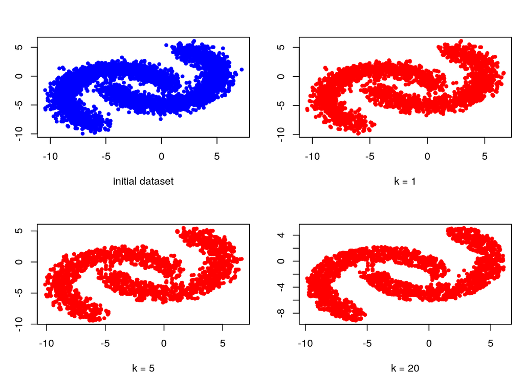

```r
rm(list=ls())
source("median_tx.R")
source("boomerang.R")
source("island.R")

l <- boomerang(Ntrn = c(2000,2000), Ntst = c(100,100), ntst_outlier = 200, s=0.7,
               show = FALSE, seed=1)
xtrn <- l[[1]]
X <- xtrn[,-ncol(xtrn)]

Y1 <- mediantx(X, k = 1, verbose = FALSE)
Y5 <- mediantx(X, k = 5, verbose = FALSE)
Y20 <- mediantx(X, k = 20, verbose = FALSE)

png(filename="mediantx_boomerang.png")
par(mfrow=c(2,2), mar = c(4,3,3,1))
plot(X,col="blue",pch=20,xlab = "initial dataset", ylab = NA)
plot(Y1,col="red",pch=20,xlab = paste("k = 1"), ylab = NA)
plot(Y5,col="red",pch=20,xlab = paste("k = 5"), ylab = NA)
plot(Y20,col="red",pch=20,xlab = paste("k = 20"), ylab = NA)
invisible(dev.off())

par(mfrow=c(2,2), mar = c(4,3,3,1))
plot(X,col="blue",pch=20,xlab = "initial dataset", ylab = NA)
plot(Y1,col="red",pch=20,xlab = paste("k = 1"), ylab = NA)
plot(Y5,col="red",pch=20,xlab = paste("k = 5"), ylab = NA)
plot(Y20,col="red",pch=20,xlab = paste("k = 20"), ylab = NA)
```

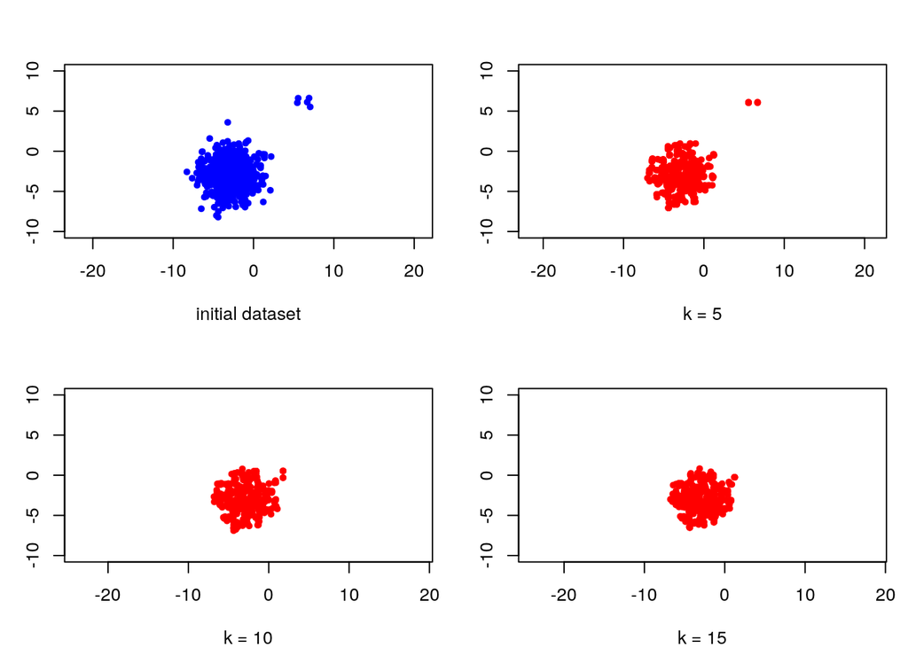

```r
#island of 5 outliers
l <- island(ntrn_inlier=c(500,5), ntst_inlier=c(100,5), ntst_outlier=100,
            show=FALSE, seed=1)
xtrn <- l[[1]]
X <- xtrn[,-ncol(xtrn)]

Y5 <- mediantx(X, k = 5, verbose = FALSE)
Y10 <- mediantx(X, k = 10, verbose = FALSE)
Y15 <- mediantx(X, k = 15, verbose = FALSE)

png(filename="mediantx_island.png")
par(mfrow=c(2,2), mar = c(4,3,3,1))
plot(X,col="blue",pch=20,xlab = "initial dataset", ylab = NA, ylim = c(-10,10), asp = 1)
plot(Y5,col="red",pch=20,xlab = paste("k = 5"), ylab = NA, ylim = c(-10,10), asp = 1)
plot(Y10,col="red",pch=20,xlab = paste("k = 10"), ylab = NA, ylim = c(-10,10), asp = 1)
plot(Y15,col="red",pch=20,xlab = paste("k = 15"), ylab = NA, ylim = c(-10,10), asp = 1)
invisible(dev.off())

par(mfrow=c(2,2), mar = c(4,3,3,1))
plot(X,col="blue",pch=20,xlab = "initial dataset", ylab = NA, ylim = c(-10,10), asp = 1)
plot(Y5,col="red",pch=20,xlab = paste("k = 5"), ylab = NA, ylim = c(-10,10), asp = 1)
plot(Y10,col="red",pch=20,xlab = paste("k = 10"), ylab = NA, ylim = c(-10,10), asp = 1)
plot(Y15,col="red",pch=20,xlab = paste("k = 15"), ylab = NA, ylim = c(-10,10), asp = 1)
```